# Strategic Targeting of OncomiRs in Brain Tumor Therapy: A Gene Expression Analysis Approach

Mersad Abbasi

20-03-2023

# Required Packages

```r
if (!requireNamespace("BiocManager", quietly = TRUE))
install.packages("BiocManager")

if (!requireNamespace("GEOmetadb", quietly = TRUE))
BiocManager::install("GEOmetadb")
if (!requireNamespace("edgeR"))
    install.packages("edgeR", quietly=TRUE)


#edgeR package was not avaialabe at CRAN so I tried bioconductor instead
if (!require("BiocManager", quietly = TRUE))
    install.packages("BiocManager")

BiocManager::install("edgeR")
```

# Load Required Packages

```r
library(GEOmetadb)
library(BiocManager)
library(knitr)
library(edgeR)
library(dplyr)
library(kableExtra)
library(biomaRt)
```

# Article Title: Anti-seed PNAs targeting multiple oncomiRs for brain tumor therapy(Wang et al. 2023),

# Importance :

Brain tumors represent a critical medical challenge due to their high lethality. This research explores the modulation of a complex gene network by two microRNAs (miRNAs) and examines the effects of targeting these miRNAs on gene expression. Additionally, it highlights the potential of using short (8-mer) γ-modified peptide nucleic acids (PNAs) as an indirect method to modify gene expression, offering promising avenues for future gene therapy.

# Conclusion:

Our findings indicate that bioengineered nanoparticle systems (BNPs) carrying anti-seed γ-modified peptide nucleic acids (sγPNAs) targeting various oncogenic microRNAs (oncomiRs) offer a viable strategy for enhancing glioblastoma multiforme (GBM) therapy. This approach also holds the potential for tailoring treatments to individual patients by targeting tumor-specific oncomiRs(Wang et al. 2023)

### FETCHING THE DATASET : GSE217366

```r
gse <- getGEO("GSE217366",GSEMatrix=FALSE)
sfiles = getGEOSuppFiles('GSE217366')
fnames = rownames(sfiles)
ExpDataset = read.delim(fnames[1],header=TRUE,
check.names = FALSE)
#we need to set check.names to false in order to avoid changing of col names if there are special characters in col names. We ensure this way that we don't lose information associated with our data


#number of genes in our dataset
dim(ExpDataset)
```

```
## [1] 35741    14
```

## Define Groups :

There are 2 groups in our study : Condition and Replicate. The last character in our sample names indicate the replicate number.

```r
#Split our sample names in 2 by splitting on the last character.
SamplesInfo <- data.frame(lapply(colnames(ExpDataset)[2:13],
                                  FUN=function(x){unlist(strsplit(x, "(?<=.)(?=[^.]$)", perl=TRUE))[c(1,2)]}))

#Name the two new groups as Condition and Replicate
colnames(SamplesInfo) <- colnames(ExpDataset)[2:13]
rownames(SamplesInfo) <- c("Condition", "replicate")

#Transform our data set into data frame
SamplesInfo <- data.frame(t(SamplesInfo))

#Visualize the two new groups and assignmed sample names
SamplesInfo
```

```
##                Condition replicate
## Control-1       Control-         1
## Control-2       Control-         2
## Control-3       Control-         3
## PNA-10b-1       PNA-10b-         1
## PNA-10b-2       PNA-10b-         2
## PNA-10b-3       PNA-10b-         3
## PNA-21-1         PNA-21-         1
## PNA-21-2         PNA-21-         2
## PNA-21-3         PNA-21-         3
## PNA-10b+21-1 PNA-10b+21-         1
## PNA-10b+21-2 PNA-10b+21-         2
## PNA-10b+21-3 PNA-10b+21-         3
```

## Check For Duplication

```r
#to find duplicated genes we need to create summary of genes table
summarized_gene_counts <- sort(table(ExpDataset$gene_name),
decreasing = TRUE)
kable(summarized_gene_counts[which(summarized_gene_counts>1)[1:10]],)
```

| Var1 | Freq |
| --- | --- |
| Y_RNA | 238 |
| Metazoa_SRP | 61 |
| U3 | 10 |
| SNORA70 | 7 |
| U8 | 6 |
| U6 | 5 |
| SNORA75 | 4 |
| U1 | 4 |
| U2 | 4 |
| U4 | 4 |

## Remove Low Count Genes

```r
#to filter out noise meaning low count genes translate out counts into counts per million using the edgeR package function cpm

cpms = cpm(ExpDataset[,2:13])
rownames(cpms) <- ExpDataset[,1]

# get rid of low counts
keep = rowSums(cpms >1) >=3
ExpDataset_filtered = ExpDataset[keep,]
```

```r
#Did we manage to reduce gene duplication?
dim(ExpDataset_filtered)
```

```
## [1] 14397    14
```

```r
dim(ExpDataset)
```

```
## [1] 35741    14
```

```r
summarized_gene_counts_filtered <- sort(table(ExpDataset_filtered$gene_name),
decreasing = TRUE)
kable(summarized_gene_counts_filtered[
which(summarized_gene_counts_filtered>1)[1:10]], format = "html")
```

| Var1 | Freq |
| --- | --- |
| AHRR | 2 |
| HSPA14 | 2 |
| TBCE | 2 |
| NA | NA |
| NA | NA |
| NA | NA |
| NA | NA |
| NA | NA |
| NA | NA |
| NA | NA |

```r
#we got rid of almost all of the gene duplications except in 3 genes named : AHRR, HSPA14 and TBCE
```

### NORMALIZATION

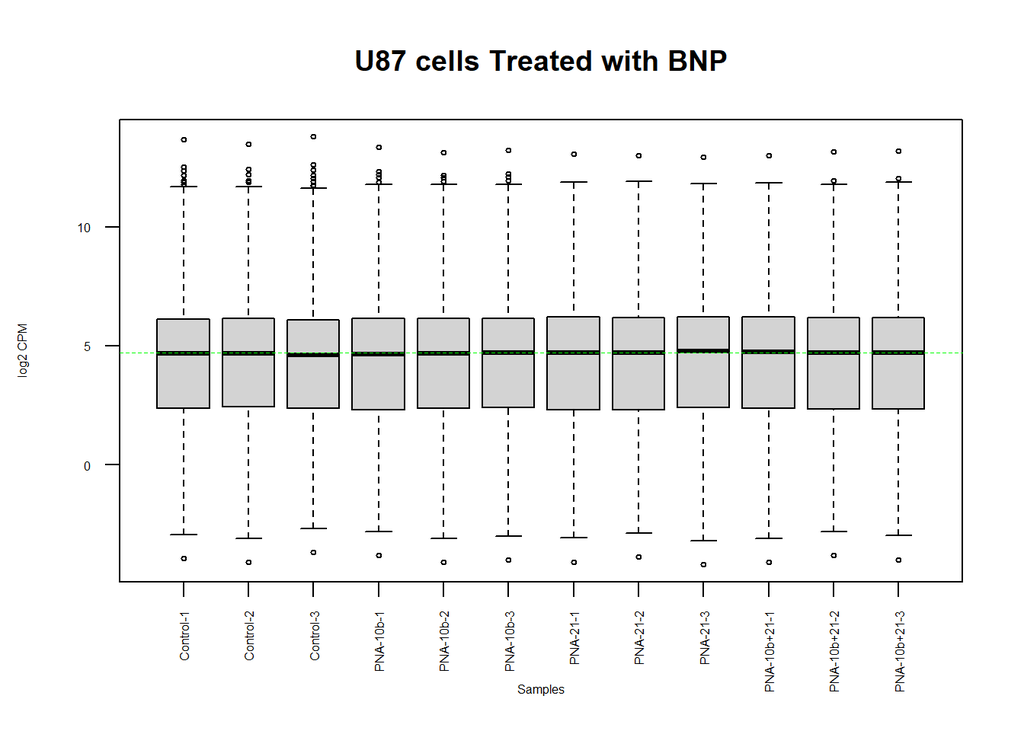

```r
#First, we visualize our data in boxplot
data2plot <- log2(cpm(ExpDataset_filtered[,2:13]))
boxplot(data2plot, xlab = "Samples", ylab = "log2 CPM",
las = 2, cex = 0.5, cex.lab = 0.5,
cex.axis = 0.5, main = "U87 cells Treated with BNP")

#draw the median on each box plot
abline(h = median(apply(data2plot, 2, median)),
col = "green", lwd = 0.6, lty = "dashed")
```

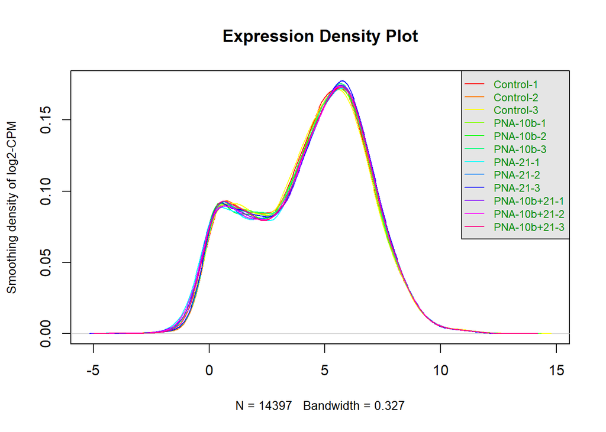

```r
#Next, we draw a density plot
counts_density <- apply(log2(cpm(ExpDataset_filtered[,2:13])),
2, density)

#calculate the limits across all the samples
xlim <- 0; ylim <- 0
for (i in 1:length(counts_density)) {
xlim <- range(c(xlim, counts_density[[i]]$x));
ylim <- range(c(ylim, counts_density[[i]]$y))
}
cols <- rainbow(length(counts_density))
ltys <- rep(1, length(counts_density))

#plot the first density plot to initialize the plot
plot(counts_density[[1]], xlim=xlim, ylim=ylim, type="n",
ylab="Smoothing density of log2-CPM",
main="Expression Density Plot", cex.lab = 0.85,)

#plot each line
for (i in 1:length(counts_density))
lines(counts_density[[i]], col=cols[i], lty=ltys[i])

#create legend
legend("topright", colnames(data2plot),
col=cols, lty=ltys, cex=0.75,
border ="blue", text.col = "green4",
merge = TRUE, bg = "gray90")
```

## Normalization by TMM

```r
filtered_data_matrix <- as.matrix(ExpDataset_filtered[,2:13])
rownames(filtered_data_matrix) <- ExpDataset_filtered$geneID
d = DGEList(counts=filtered_data_matrix, group = SamplesInfo$Condition)

d = calcNormFactors(d)
#get the normalized data
normalized_counts <- cpm(d)
```

# Compare normalized and pre-normalized data :

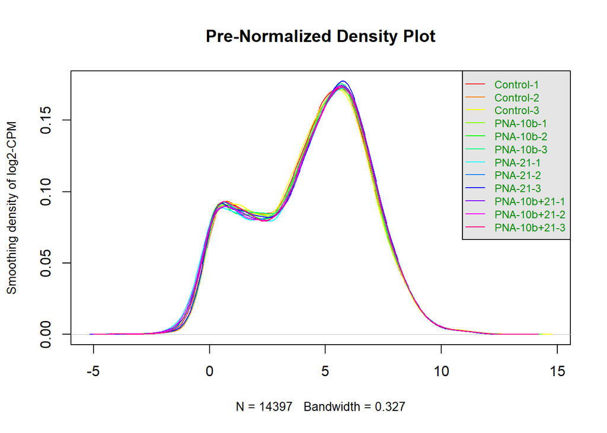

```r
# pre-normalized Density Plot
counts_density <- apply(log2(cpm(ExpDataset_filtered[,2:13])),
2, density)
#calculate the limits across all the samples
xlim <- 0; ylim <- 0
for (i in 1:length(counts_density)) {
xlim <- range(c(xlim, counts_density[[i]]$x));
ylim <- range(c(ylim, counts_density[[i]]$y))
}
cols <- rainbow(length(counts_density))
ltys <- rep(1, length(counts_density))

plot(counts_density[[1]], xlim=xlim, ylim=ylim, type="n",
ylab="Smoothing density of log2-CPM",
main="Pre-Normalized Density Plot", cex.lab = 0.85)
#plot each line
for (i in 1:length(counts_density))
lines(counts_density[[i]], col=cols[i], lty=ltys[i])
#create legend
legend("topright", colnames(data2plot),
col=cols, lty=ltys, cex=0.75,
border ="blue", text.col = "green4",
merge = TRUE, bg = "gray90")
```

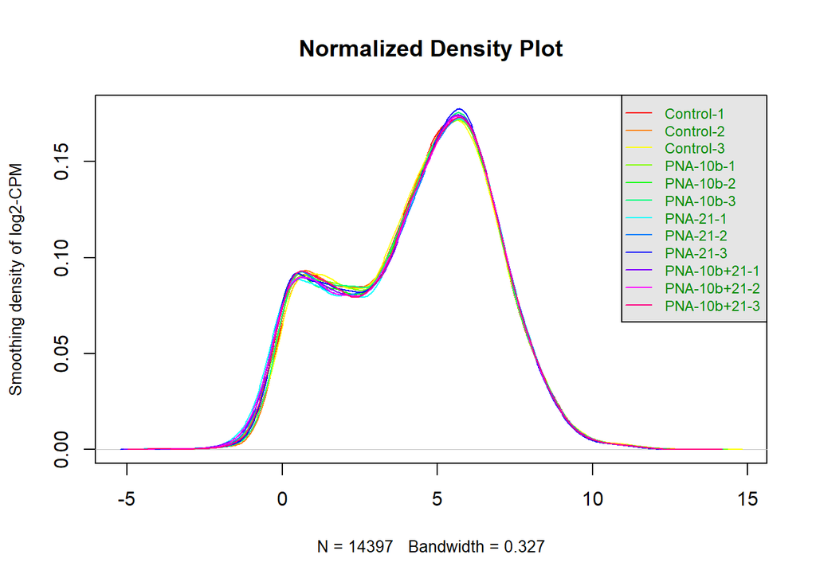

```r
# normalized Density Plot
normalized_counts_density <- apply(log2(cpm(d)),
2, density)
#calculate the limits across all the samples
xlim <- 0; ylim <- 0
for (i in 1:length(normalized_counts_density)) {
xlim <- range(c(xlim, normalized_counts_density[[i]]$x));
ylim <- range(c(ylim, normalized_counts_density[[i]]$y))
}
cols <- rainbow(length(normalized_counts_density))
ltys <- rep(1, length(normalized_counts_density))

plot(normalized_counts_density[[1]], xlim=xlim, ylim=ylim, type="n",
ylab="Smoothing density of log2-CPM",
main="Normalized Density Plot", cex.lab = 0.85)
#plot each line
for (i in 1:length(normalized_counts_density))
lines(normalized_counts_density[[i]], col=cols[i], lty=ltys[i])
#create legend
legend("topright", colnames(data2plot),
col=cols, lty=ltys, cex=0.75,
border ="blue", text.col = "green4",
merge = TRUE, bg = "gray90")
```

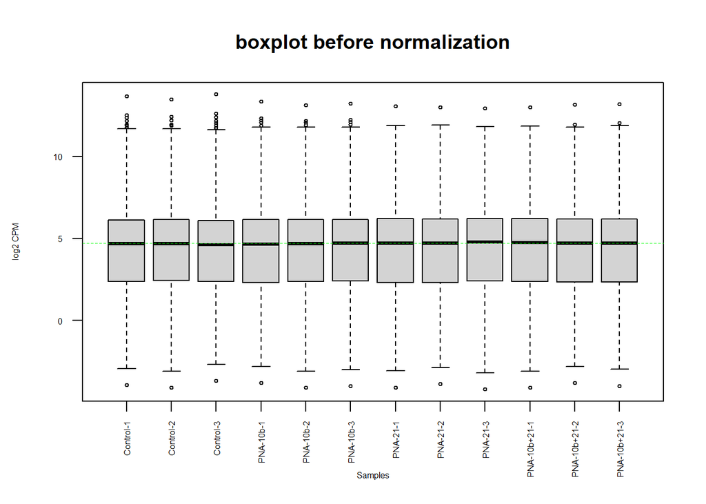

```r
# Pre-Normalized Boxplot
data2plot <- log2(cpm(ExpDataset_filtered[,2:13]))
boxplot(data2plot, xlab = "Samples", ylab = "log2 CPM",
las = 2, cex = 0.5, cex.lab = 0.5,
cex.axis = 0.5, main = "boxplot before normalization")
#draw the median on each box plot
abline(h = median(apply(data2plot, 2, median)),
col = "green", lwd = 0.6, lty = "dashed")
```